# Mini Project

’Joba Adisa

2022-10-03

[output not shown]

## Setup

```r
knitr::opts_chunk$set(echo = TRUE, message = FALSE, warning = FALSE)
```

## Introduction

In this assignment I used linear regression modeling to analyze the relationship between South Carolina (SC) schools average SAT Mathematics Score and the following variables:

1. SAT - Average Critical Reading Score
2. Student-teacher ratio in core subjects - Current year
3. Percent of teachers with advanced degrees - Current year
4. Percent of teachers returning from previous year - three year average - Current year

The analysis is conducted using data from the 2021 South Carolina school report card data, and the analysis is limited to only traditional high schools is SC.

The analysis addresses the following question:

> Are the following variables (1) Average Critical Reading Score, (2) Student-teacher ratio in core subjects, (3) Percent of teachers with advanced degrees - Current year, and (4) Percent of teachers returning from previous year - three year average - Current year, significant predictors of average SAT Mathematic scores in SC traditional high schools?

The initial multiple linear regression model to predict the average SAT score in Mathematics for schools in SC from the identified explanatory variables above is as follow

$$sat\_avg\_math\_score = \beta_0 + \beta_1sat\_avg\_crit\_reading\_score
+ \beta_2student\_teacher\_ratio\_curr\_yr +
\beta_3tchadvdegree\_pct\_curr\_yr
+ \beta_4tchreturn3yr\_avg\_pct\_curr\_yr + \epsilon$$

**Justification**

My decision to explore the relationship between these variables is influenced by the belief that students who are good critical readers would likely perform better at mathematics too since they would be able to pay attention to details. Additionally, I am of the opinion that a moderate students to teacher ratio will give teachers the opportunity to allocate more time for supporting individual students, while the opposite will likely be the case for schools with high student-teacher-ratio. I also wanted to see whether teachers additional qualifications has any impact on students’ success in their SAT. Every year, many schools and district sponsor teachers to get an advanced degree or training and I’m interested to see if this initiative influences students’ success in any way. Finally, I think when teachers consistently teach a course, they get better at it and establish good relationship with students, hence the decision to see whether the percentage of returning teachers over an three year average will influence schools’ average SAT Math score in any way.

My initial assessment is that all four variables will be a significant predictor of students’ average SAT Mathematics scores in these schools.

The sections that follow details how the data is explored, cleaned and analyzed in order to fit the model and obtain the best fitted model for predicting average SAT scores from the selected explanatory variables in the model.

## Loading Packages

```r
library(readxl)  # for reading SC report card excel data
library(janitor)  # for cleaning variable names
library(tidyverse)  # for analysis of the data
library(dataedu)
library(sjPlot)
library(GGally)
```

## Importing Data

```r
# Loading the SAT Scores Data
AverageAssessmentData <- read_excel("data/ReportCardData_AdditionalInfo2021.XLSx", sheet = 6, na = "*", skip = 0)


# Loading the Classroom Environment Data
ClassroomEnvironmentData <- read_excel("data/ReportCardData_AdditionalInfo2021.XLSx", sheet = 11, na = c("*", "N/AV", "NA in 2020"), skip = 0)
```

### Initial Data Exploration

```r
# getting the first few observations in the scores data
glimpse(AverageAssessmentData)
```

```
## Rows: 340
## Columns: 27
## $ ReportCardYear                <dbl> 2021, 2021, 2021, 2021, 2021, 2021, 2021…
## $ DistrictNm                    <chr> "Abbeville County School\r\nDistrict", "…
## $ SchoolNm                      <chr> "Abbeville High School", "Dixie High Sch…
## $ SCHOOLID                      <dbl> 160001, 160003, 160999, 201001, 201002, …
## $ SCHOOLTYPECD                  <chr> "H", "H", "D", "H", "H", "H", "H", "H", …
## $ ACT_Avg_EnglishScore          <dbl> 16.3, 18.8, 17.1, 12.9, 15.7, 17.6, 15.2…
## $ ACT_Avg_ReadingScore          <dbl> 17.5, 21.7, 18.9, 13.9, 17.4, 19.7, 17.1…
## $ ACT_Avg_MathScore             <dbl> 17.5, 21.9, 19.0, 15.8, 16.9, 19.1, 17.0…
## $ ACT_Avg_ScienceScore          <dbl> 18.4, 22.6, 19.8, 15.5, 17.6, 19.6, 17.5…
## $ ACT_Avg_WritingScore          <dbl> 5.1, 5.7, 5.3, 4.8, 5.7, 5.6, 5.3, 6.0, …
## $ ACT_Avg_CompositeScore        <dbl> 17.5, 21.3, 18.8, 14.6, 17.0, 19.1, 16.8…
## $ ACT_Pct_BENCHMARK_English     <dbl> 35.9, 50.0, 40.7, 11.4, 30.3, 47.8, 29.3…
## $ ACT_Pct_BENCHMARK_Reading     <dbl> 23.1, 45.0, 30.5, 6.1, 27.0, 40.5, 19.0,…
## $ ACT_Pct_BENCHMARK_Math        <dbl> 20.5, 55.0, 32.2, 3.5, 13.9, 32.2, 11.6,…
## $ ACT_Pct_BENCHMARK_Sci         <dbl> 20.5, 60.0, 33.9, 5.3, 20.5, 29.8, 12.2,…
## $ ACT_Pct_BENCHMARK_All4        <dbl> 15.4, 35.0, 22.0, 0.9, 9.0, 20.0, 6.1, 1…
## $ SAT_PctTested                 <dbl> 54.9, 60.3, 57.1, 35.6, 62.7, 60.1, 43.8…
## $ SAT_Avg_CritReadingScore      <dbl> 503, 507, 504, 475, 485, 537, 507, 495, …
## $ SAT_Avg_MathScore             <dbl> 495, 500, 497, 469, 456, 512, 475, 475, …
## $ SAT_Avg_WritingScore          <dbl> 503, 507, 504, 475, 485, 537, 507, 495, …
## $ SAT_Avg_CompositeScore        <dbl> 997, 1007, 1001, 944, 941, 1048, 981, 97…
## $ DUAL_NumStudEnroll            <dbl> 75, 53, 128, 31, 75, 78, 90, 43, 18, 19,…
## $ DUAL_PctStuEnroll             <dbl> 35.7, 34.2, 35.1, 11.3, 14.3, 12.7, 19.1…
## $ DUAL_Pct1112StuComplete2Cplus <dbl> 72.0, 66.0, 69.5, 41.9, 58.7, 67.9, 77.8…
## $ AP_PctPass                    <dbl> 100.0, 55.6, 69.2, 10.7, 35.4, 34.6, 12.…
## $ AP_NumExams                   <dbl> 4, 9, 13, 205, 158, 769, 190, 739, 25, 3…
## $ AP_NumPartic                  <dbl> 4, 9, 13, 138, 102, 454, 162, 432, 23, 2…
```

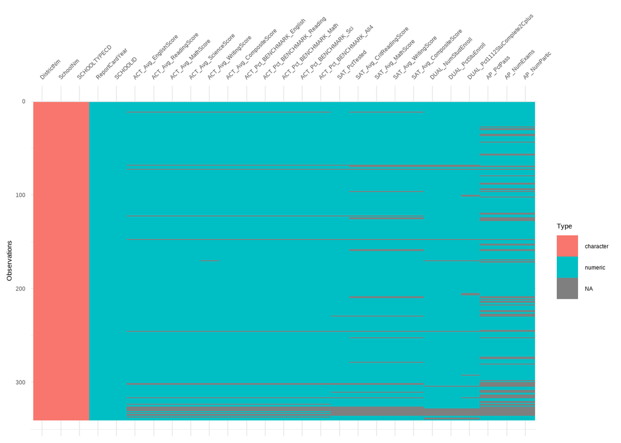

Fig.1: Distibution of Data Types in the Average Assessment Data

```r
# Using the vis_dat() in the visdat package to explore the data types in our data
visdat::vis_dat(AverageAssessmentData)
```

Initial exploration shows that the assessment data set which contains schools average SAT scores has 340 rows and 27 columns. The data contains numeric data, characters and a lot of missing data too.

```r
# getting the first few observations in the classroom env. data
glimpse(ClassroomEnvironmentData)
```

```
## Rows: 1,409
## Columns: 33
## $ ReportCardYear                <dbl> 2021, 2021, 2021, 2021, 2021, 2021, 2021…
## $ DistrictNm                    <chr> "Abbeville County School\r\nDistrict", "…
## $ SchoolNm                      <chr> "Abbeville High School", "Dixie High Sch…
## $ SCHOOLID                      <chr> "0160001", "0160003", "0160007", "016001…
## $ SCHOOLTYPECD                  <chr> "H", "H", "E", "M", "E", "E", "M", "E", …
## $ TCHNUMBER_CurrYr              <dbl> 34, 30, 14, 31, 25, 28, 28, 21, 21, 29, …
## $ TCHNUMBER_LastYr              <dbl> 35, 31, 14, 34, 26, 29, 29, 21, 21, 28, …
## $ TCHADVDEGREE_PctCurrYr        <dbl> 67.64706, 59.16667, 92.85714, 54.83871, …
## $ TCHADVDEGREE_PctLastYr        <dbl> 60.0, 51.6, 92.9, 70.6, 65.4, 65.5, 65.5…
## $ TCHATTENDRATE_CurrYr          <dbl> 92.3, 94.3, 96.9, 93.8, 91.9, 92.3, 92.3…
## $ TCHATTENDRATE_LastYr          <lgl> NA, NA, NA, NA, NA, NA, NA, NA, NA, NA, …
## $ TCHSALARY_AvgCurrYr           <dbl> 51231.72, 51158.00, 52746.92, 50610.16, …
## $ TCHSALARY_AvgLastYr           <chr> "$51,261", "$50,201", "$54,236", "$53,21…
```

[output cut: 20 more lines]

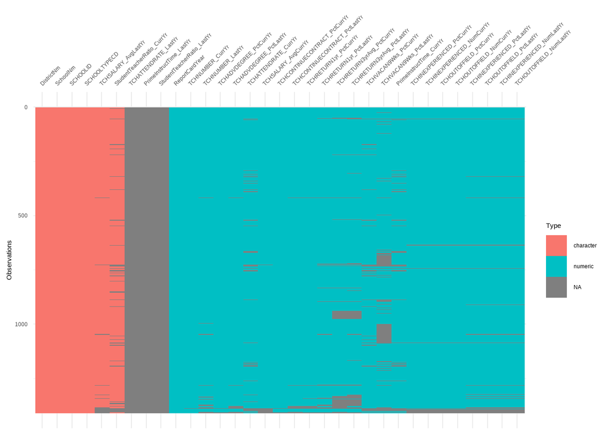

Fig.2: Distibution of Data Types in the Classroom Environment Data

```r
# Using the vis_dat() in the visdat package to explore the data types in our data
visdat::vis_dat(ClassroomEnvironmentData)
```

## Processing Data

Based on personal preference, I prefer to work with lower case variable names and I will be using the `clean_names()` function in the {janitor} package to truncate the names of the columns in both data sets. I will also remove the three empty columns in the Classroom Environment Dataset

```r
# cleaning names to make it tidy
AverageAssessmentData <- clean_names(AverageAssessmentData)
ClassroomEnvironmentData <- clean_names(ClassroomEnvironmentData)

# removing empty rows from the data set
AverageAssessmentData <- remove_empty(AverageAssessmentData, c("rows", "cols"))
ClassroomEnvironmentData <- remove_empty(ClassroomEnvironmentData, c("rows", "cols"))

# renaming column names to make it tidy
AverageAssessmentData <-
  AverageAssessmentData %>%
  rename(school_id = schoolid,
         school_type_cd = schooltypecd)

ClassroomEnvironmentData <-
  ClassroomEnvironmentData %>%
  rename(school_id = schoolid,
         school_type_cd = schooltypecd)
```

Further inspection of the data shows that *school_id* is of different data types in both data set as shown below

```r
typeof(ClassroomEnvironmentData$school_id) # outputs character
```

```
## [1] "character"
```

```r
typeof(AverageAssessmentData$school_id)  # outputs double
```

```
## [1] "double"
```

Since I will be joining both data sets using the school IDs I will need to make sure they are of the same data types in bothe data. Hence, school_id will be changed to numeric in the Classroom Environment Data as shown in block of code that follows

```r
# Saving the school_id variable as numeric
ClassroomEnvironmentData <- ClassroomEnvironmentData %>%
  mutate(school_id = as.numeric(school_id))
```

Now we can inspect the data to see the result of our operation

```r
glimpse(ClassroomEnvironmentData)
```

```
## Rows: 1,409
## Columns: 30
## $ report_card_year                <dbl> 2021, 2021, 2021, 2021, 2021, 2021, 20…
## $ district_nm                     <chr> "Abbeville County School\r\nDistrict",…
## $ school_nm                       <chr> "Abbeville High School", "Dixie High S…
## $ school_id                       <dbl> 160001, 160003, 160007, 160016, 160017…
## $ school_type_cd                  <chr> "H", "H", "E", "M", "E", "E", "M", "E"…
## $ tchnumber_curr_yr               <dbl> 34, 30, 14, 31, 25, 28, 28, 21, 21, 29…
## $ tchnumber_last_yr               <dbl> 35, 31, 14, 34, 26, 29, 29, 21, 21, 28…
## $ tchadvdegree_pct_curr_yr        <dbl> 67.64706, 59.16667, 92.85714, 54.83871…
## $ tchadvdegree_pct_last_yr        <dbl> 60.0, 51.6, 92.9, 70.6, 65.4, 65.5, 65…
## $ tchattendrate_curr_yr           <dbl> 92.3, 94.3, 96.9, 93.8, 91.9, 92.3, 92…
## $ tchsalary_avg_curr_yr           <dbl> 51231.72, 51158.00, 52746.92, 50610.16…
## $ tchsalary_avg_last_yr           <chr> "$51,261", "$50,201", "$54,236", "$53,…
## $ tchcontinuecontract_pct_curr_yr <dbl> 100.00000, 96.66667, 100.00000, 100.00…
```

[output cut: 17 more lines]

Next step is to Join both data sets by the School ID and School Type column into a new data set called *sc_education_data*.

```r
# left join both data sets
sc_education_data <-
  left_join(AverageAssessmentData, ClassroomEnvironmentData,
            by = c("school_id", "school_type_cd"))

dim(sc_education_data)
```

```
## [1] 342  55
```

The combined data set has a dimension of 342 rows and 55 columns representing SC schools with average SAT scores in various subjects. Since my analysis is limited to traditional high schools in SC, I will use the filter function to limit the data set to only those that are high schools. Further filtering will be done using the str_detect() function in tidyverse {stringr} package to make sure only traditional high schools are selected. This involves removing any school name that includes the strings “Academy”, “Charter”, “College”, “Magnet”, “School Of”, or “School For” as well as any district name that includes the strings “Charter”, “Unified”, or “Governor’s”.

```r
# reducing observation to only high schools (H)
sc_highschool_data <- sc_education_data %>%
  filter(school_type_cd == "H")  # outputs 252 observations

# Reducing observation to only traditional high schools
sc_highschool_data <- sc_highschool_data %>%
  filter(str_detect(school_nm.x, "Academy|Charter|College|Magnet|School Of|School For", negate = TRUE)) %>%
  filter(str_detect(district_nm.x, "Charter|Unified|Governor's", negate = TRUE))  # returns 193 observations

# Taking a glimpse at the data set
glimpse(sc_highschool_data)
```

```
## Rows: 193
## Columns: 55
## $ report_card_year.x              <dbl> 2021, 2021, 2021, 2021, 2021, 2021, 20…
## $ district_nm.x                   <chr> "Abbeville County School\r\nDistrict",…
## $ school_nm.x                     <chr> "Abbeville High School", "Dixie High S…
## $ school_id                       <dbl> 160001, 160003, 201001, 201002, 201003…
## $ school_type_cd                  <chr> "H", "H", "H", "H", "H", "H", "H", "H"…
## $ act_avg_english_score           <dbl> 16.3, 18.8, 12.9, 15.7, 17.6, 15.2, 17…
## $ act_avg_reading_score           <dbl> 17.5, 21.7, 13.9, 17.4, 19.7, 17.1, 19…
## $ act_avg_math_score              <dbl> 17.5, 21.9, 15.8, 16.9, 19.1, 17.0, 18…
## $ act_avg_science_score           <dbl> 18.4, 22.6, 15.5, 17.6, 19.6, 17.5, 19…
## $ act_avg_writing_score           <dbl> 5.1, 5.7, 4.8, 5.7, 5.6, 5.3, 6.0, 4.6…
## $ act_avg_composite_score         <dbl> 17.5, 21.3, 14.6, 17.0, 19.1, 16.8, 19…
## $ act_pct_benchmark_english       <dbl> 35.9, 50.0, 11.4, 30.3, 47.8, 29.3, 47…
## $ act_pct_benchmark_reading       <dbl> 23.1, 45.0, 6.1, 27.0, 40.5, 19.0, 38.…
```

[output cut: 42 more lines]

A glimpse at the data set shows that the observation has been reduced to 193 Traditional High Schools. The student to teacher ratio columns however needs further tidying. It contains entry that are currently in form of a sentence, for example, we have “22.5 to 1” as the ratio of students to teachers. We can just stick to the number of students for the purpose of this analysis. This will be addressed using the mutate() function as shown in the block of code below.

```r
# selecting only the number of students and converting it to a numeric data type
sc_highschool_data <- sc_highschool_data %>%
  mutate(student_teacher_ratio_curr_yr = as.numeric(str_sub(student_teacher_ratio_curr_yr, start = 1, end = 4)))
```

Next I will use the `select()` function to reduce the data set to only include useful identifiers and the variables of interest in my chosen model. This include district name, school name, school ID, and student avg_sat_mat_score,

```r
# Selecting a subset of the data for analysis
df <- sc_highschool_data %>%
  select(school_id,
         district_nm.x,
         school_nm.x,
         sat_avg_math_score,
         sat_avg_crit_reading_score,
         tchadvdegree_pct_curr_yr,
         student_teacher_ratio_curr_yr,
         tchreturn3yr_avg_pct_curr_yr)
```

```r
# renaming the column names
df <- df %>%
  rename(school_name = school_nm.x,
         district_name = district_nm.x)

head(df)
```

```
## # A tibble: 6 × 8
##   school_id district_name        schoo…¹ sat_a…² sat_a…³ tchad…⁴ stude…⁵ tchre…⁶
##       <dbl> <chr>                <chr>     <dbl>   <dbl>   <dbl>   <dbl>   <dbl>
## 1    160001 "Abbeville County S… Abbevi…     495     503    67.6    22.5    94.9
## 2    160003 "Abbeville County S… Dixie …     500     507    59.2    26.6    86.7
## 3    201001 "Aiken County Publi… Silver…     469     475    67.6    27.1    78.8
## 4    201002 "Aiken County Publi… Aiken …     456     485    65.3    29.6    87.1
## 5    201003 "Aiken County Publi… South …     512     537    56.5    29.3    89.4
## 6    201006 "Aiken County Publi… Midlan…     475     507    56.4    26.7    79.3
## # … with abbreviated variable names ¹school_name, ²sat_avg_math_score,
## #   ³sat_avg_crit_reading_score, ⁴tchadvdegree_pct_curr_yr,
## #   ⁵student_teacher_ratio_curr_yr, ⁶tchreturn3yr_avg_pct_curr_yr
```

## Analysis

This analysis will include three components: a univariate data analysis, a bivariate data analysis, and a linear regression analysis.

### Univariate Analysis

For the univariate analysis, I will plot a distribution of each of the selected variables using a box plot. Next I will calculate the summary statistics for each of the variables including the mean, standard deviation, minimum, maximum, median, and IQR.

### Distribution of average SAT Maths Scores 2021

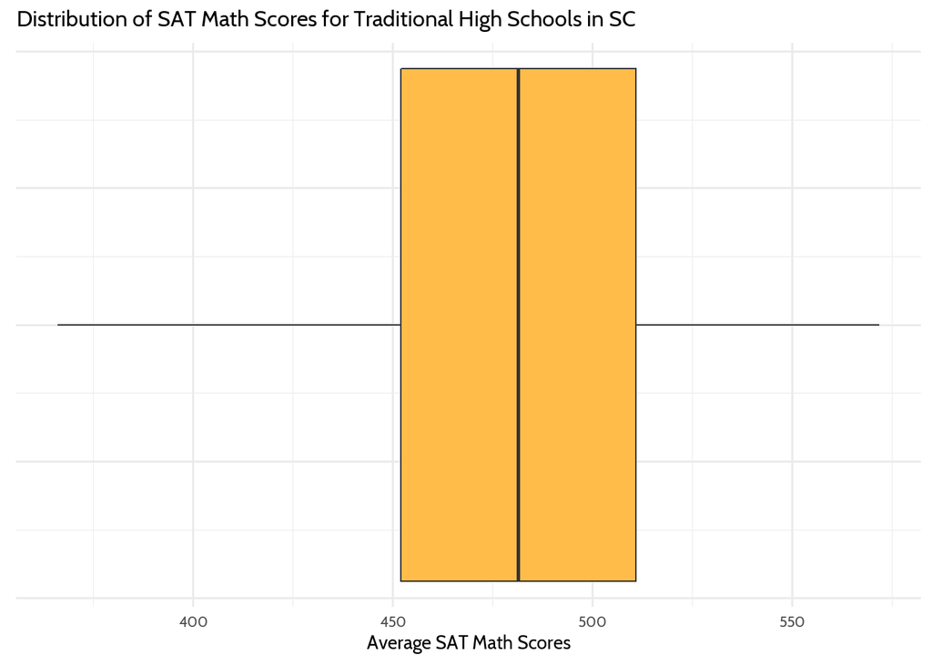

Fig.3: 2021 Distribution of SAT Math Scores for Traditional High Schools in SC

```r
df %>%
  ggplot(aes(x=sat_avg_math_score)) +
  geom_boxplot(fill = dataedu_colors("yellow")) +
  theme_dataedu() +
    theme(text = element_text(size=20), axis.text.y=element_blank(),
        axis.ticks.y=element_blank()) +
  labs(title = "Distribution of SAT Math Scores for Traditional High Schools in SC",
       x = "Average SAT Math Scores")
```

The Summary Statistics for this distribution is as follow:

```r
df %>%
  summarise("Minimun" = min(sat_avg_math_score, na.rm = TRUE),
            "Median" = median(sat_avg_math_score, na.rm = TRUE),
            "Maximum" = max(sat_avg_math_score, na.rm = TRUE),
            "IQR" = IQR(sat_avg_math_score, na.rm = TRUE),
            "Mean" = mean(sat_avg_math_score, na.rm = TRUE),
            "SD" = sd(sat_avg_math_score, na.rm = TRUE),
            n = n())
```

```
## # A tibble: 1 × 7
##   Minimun Median Maximum   IQR  Mean    SD     n
##     <dbl>  <dbl>   <dbl> <dbl> <dbl> <dbl> <int>
## 1     366   482.     572    59  480.  40.9   193
```

The boxplot shows that there is a considerable amount of variation in the average SAT Math Scores for SC high schools in the year 2021, with the minimum score being 366 and maximum score being 572 while the median score is 481.5. The plot also appear to be fairly symmetry even though the mean (mean=480.0924) is slightly lower than the median due to the minimum score, however, it is not considered an outlier.

### Distribution of average SAT Critical Reading Scores 2021

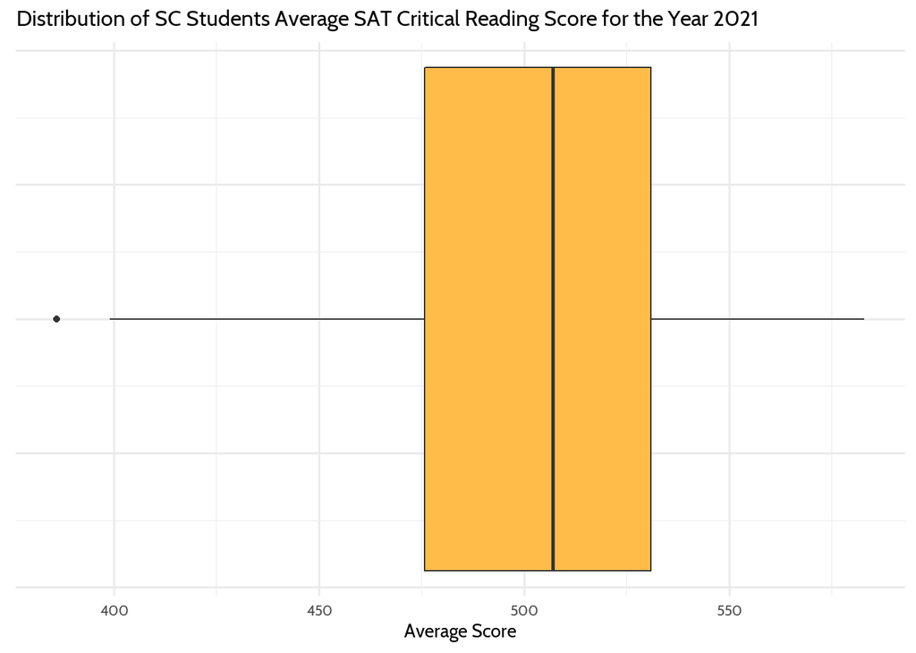

Fig.4: 2021 Distribution of SAT Critical Reading Scores for Traditional High Schools in SC

```r
df %>%
  ggplot(aes(x=sat_avg_crit_reading_score)) +
  geom_boxplot(fill = dataedu_colors("yellow")) +
  theme_dataedu() +
    theme(text = element_text(size=20), axis.text.y=element_blank(),
        axis.ticks.y=element_blank()
        ) +
  labs(title = "Distribution of SC Students Average SAT Critical Reading Score for the Year 2021",
       x = "Average Score")
```

The Summary Statistics for this distribution is as follow:

```r
df %>%
  summarise("Minimun" = min(sat_avg_crit_reading_score, na.rm = TRUE),
            "Median" = median(sat_avg_crit_reading_score, na.rm = TRUE),
            "Maximum" = max(sat_avg_crit_reading_score, na.rm = TRUE),
            "IQR" = IQR(sat_avg_crit_reading_score, na.rm = TRUE),
            "Mean" = mean(sat_avg_crit_reading_score, na.rm = TRUE),
            "SD" = sd(sat_avg_crit_reading_score, na.rm = TRUE),
            n = n())
```

```
## # A tibble: 1 × 7
##   Minimun Median Maximum   IQR  Mean    SD     n
##     <dbl>  <dbl>   <dbl> <dbl> <dbl> <dbl> <int>
## 1     386    507     583  55.2  502.  38.5   193
```

The boxplot shows that there is a considerable amount of variation in the average SAT Crtical Reading Scores for SC high schools in the year 2021, with the minimum score being 386 and maximum score being 583 while the median score is 507. The plot also appear to be skewed to the left evidenced by the longer lower tail of the box plot and the mean score (mean=502.39) that is lower than the median. The minimum score is also an outlier that pull the mean in its direction.

### Distribution of SC Schools Student-Teacher Ratio in Core Subject

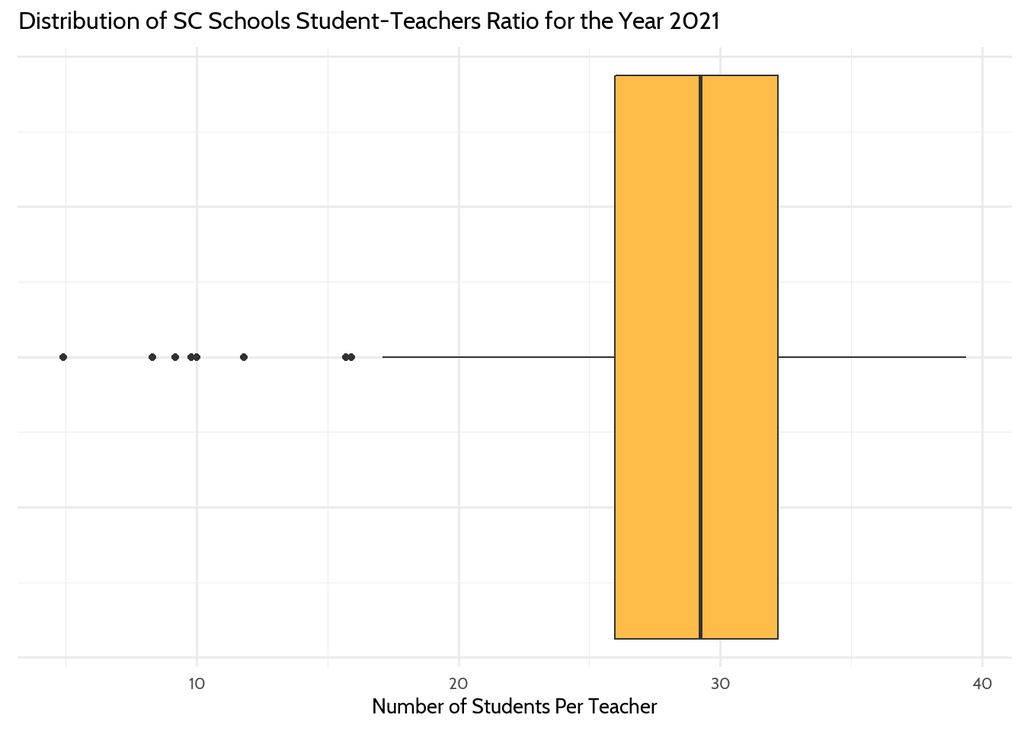

Fig.5: 2021 Distribution of Average Student-to-Teacher Ratio for Traditional High Schools in SC

```r
df %>%
  ggplot(aes(x=student_teacher_ratio_curr_yr)) +
  geom_boxplot(fill = dataedu_colors("yellow")) +
  theme_dataedu() +
  theme(text = element_text(size=20), axis.text.y=element_blank(),
        axis.ticks.y=element_blank()
        ) +
  labs(title = "Distribution of SC Schools Student-Teachers Ratio for the Year 2021",
       x = "Number of Students Per Teacher")
```

The Summary Statistics is for this distribution is as follow:

```r
df %>%
  summarise("Minimun" = min(student_teacher_ratio_curr_yr, na.rm = TRUE),
            "Median" = median(student_teacher_ratio_curr_yr, na.rm = TRUE),
            "Maximum" = max(student_teacher_ratio_curr_yr, na.rm = TRUE),
            "IQR" = IQR(student_teacher_ratio_curr_yr, na.rm = TRUE),
            "Mean" = mean(student_teacher_ratio_curr_yr, na.rm = TRUE),
            "SD" = sd(student_teacher_ratio_curr_yr, na.rm = TRUE),
            n = n())
```

```
## # A tibble: 1 × 7
##   Minimun Median Maximum   IQR  Mean    SD     n
##     <dbl>  <dbl>   <dbl> <dbl> <dbl> <dbl> <int>
## 1     4.9   29.2    39.4  6.23  28.4  5.78   193
```

The boxplot shows that there is a great amount of variation in the average Student-Teacher Ratio in Core Subjects among SC traditional high schools for the year 2021. The distribution is also skewed to the left with a lot of outliers.

### Distribution of Average SC Schools Teachers with an Advanced Degree

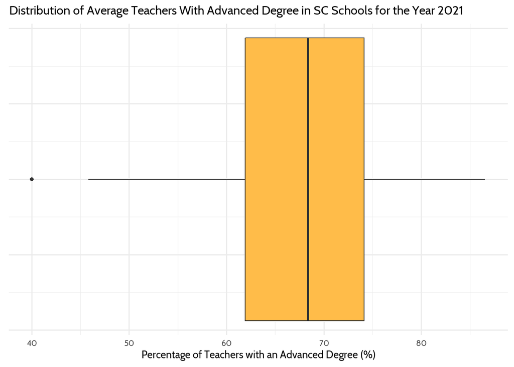

Fig.6: 2021 Distribution of Average Percentage of Teachers With an Advanced Degree in Traditional High Schools in SC

```r
df %>%
  ggplot(aes(x=tchadvdegree_pct_curr_yr)) +
  geom_boxplot(fill = dataedu_colors("yellow")) +
  theme_dataedu() +
  theme(text = element_text(size=20), axis.text.y=element_blank(),
        axis.ticks.y=element_blank()
        ) +
  labs(title = "Distribution of Average Teachers With Advanced Degree in SC Schools for the Year 2021",
       x = "Percentage of Teachers with an Advanced Degree (%)")
```

The Summary Statistics is for this distribution is as follow:

```r
df %>%
  summarise("Minimun" = min(tchadvdegree_pct_curr_yr, na.rm = TRUE),
            "Median" = median(tchadvdegree_pct_curr_yr, na.rm = TRUE),
            "Maximum" = max(tchadvdegree_pct_curr_yr, na.rm = TRUE),
            "IQR" = IQR(tchadvdegree_pct_curr_yr, na.rm = TRUE),
            "Mean" = mean(tchadvdegree_pct_curr_yr, na.rm = TRUE),
            "SD" = sd(tchadvdegree_pct_curr_yr, na.rm = TRUE),
            n = n())
```

```
## # A tibble: 1 × 7
##   Minimun Median Maximum   IQR  Mean    SD     n
##     <dbl>  <dbl>   <dbl> <dbl> <dbl> <dbl> <int>
## 1      40   68.3    86.5  12.2  67.8  8.65   193
```

The boxplot shows that there is a considerable amount of variation in the average percentage of teachers with advanced degrees among traditional SC high schools in the year 2021. The school with the minimum percentage of teachers with an advanced degree in core courses have a 40% while the maximum was 86.5% and the median percentage of teachers with advanced degree in this sample was 68.34%. The plot also appear to be skewed to the left evidenced by the longer lower tail of the box plot and the mean percentage that is lower than the median. The minimum percentage is also an outlier that pull the mean in its the direction.

### Distribution of SC Schools Teachers returning over a 3 year average

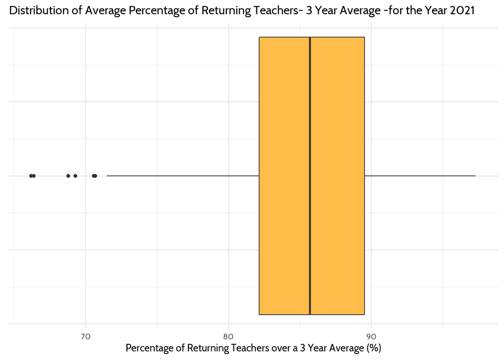

Fig.7: 2021 Distribution of Average Percentage of Teachers Returning From Previous Year - 3 Year Average - Current Year

```r
df %>%
  ggplot(aes(x=tchreturn3yr_avg_pct_curr_yr)) +
  geom_boxplot(fill = dataedu_colors("yellow")) +
  theme_dataedu() +
  theme(text = element_text(size=20), axis.text.y=element_blank(),
        axis.ticks.y=element_blank()) +
  labs(title = "Distribution of Average Percentage of Returning Teachers- 3 Year Average -for the Year 2021",
       x = "Percentage of Returning Teachers over a 3 Year Average (%)")
```

The Summary Statistics is for this distribution is as follow:

```r
df %>%
  summarise("Minimun" = min(tchreturn3yr_avg_pct_curr_yr, na.rm = TRUE),
            "Median" = median(tchreturn3yr_avg_pct_curr_yr, na.rm = TRUE),
            "Maximum" = max(tchreturn3yr_avg_pct_curr_yr, na.rm = TRUE),
            "IQR" = IQR(tchreturn3yr_avg_pct_curr_yr, na.rm = TRUE),
            "Mean" = mean(tchreturn3yr_avg_pct_curr_yr, na.rm = TRUE),
            "SD" = sd(tchreturn3yr_avg_pct_curr_yr, na.rm = TRUE),
            n = n())
```

```
## # A tibble: 1 × 7
##   Minimun Median Maximum   IQR  Mean    SD     n
##     <dbl>  <dbl>   <dbl> <dbl> <dbl> <dbl> <int>
## 1    66.2   85.7    97.3  7.38  85.0  6.03   193
```

The boxplot shows that there is a considerable amount of variation in the average percentage of returning teachers (3 year average) among traditional SC high schools in the year 2021. The school with the minimum percentage has 66% of teachers returning over an average of 3 years while the school with the maximum percentage has an estimated 97% of teachers returning over an average of 3 years in the year 2021. The plot also appear to be skewed to the left evidenced by the longer lower tail of the box plot and the mean percentage that is lower than the median.

## Bivariate Data Analysis

In this section, I provide a scatterplot and correlation matrix that includes all the variables in the chosen model.

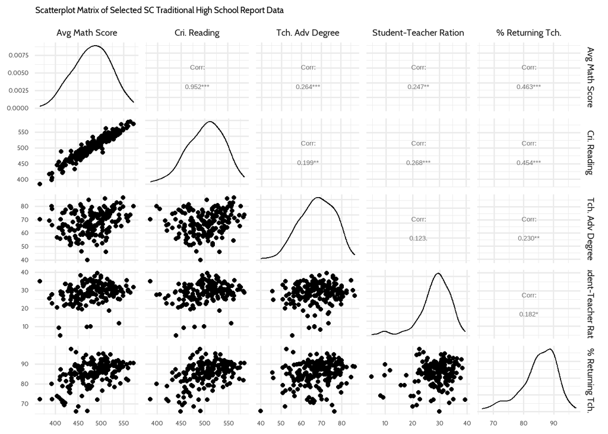

Fig.8: Scatter Plot and Correlation Matrix of the Selected Variables

```r
# Using ggpairs to create a scatterplot matrix
df %>%
  select(-c(school_id, school_name, district_name)) %>%
  ggpairs(title = "Scatterplot Matrix of Selected SC Traditional High School Report Data", columnLabels = c("Avg Math Score", "Cri. Reading", "Tch. Adv Degree", "Student-Teacher Ration", "% Returning Tch.")) +
  theme_dataedu()  +
  theme(strip.text.x = element_text(size = 15),
        strip.text.y = element_text(size = 15))
```

Since there are no categorical explanatory variables in the model, there is no need to visualize or summarize by groups.

## Linear Regression Analysis: Using Backward Elimination Method

I will use th `lm()` function to fit the initial multiple regression model that includes all of the selected explanatory variables. The model summary will thereafter be displayed using the `tab_model` function.

Model 0:

$$\hat{sat\_avg\_math\_score} = \hat\beta_0 +
\hat\beta_1(sat\_avg\_crit\_reading\_score) +
\hat\beta_2(student\_teacher\_ratio\_curr\_yr) +
\hat\beta_3(tchadvdegree\_pct\_curr\_yr) +
\hat\beta_4(tchreturn3yr\_avg\_pct\_curr\_yr)$$

```r
# fitting the model
model_0 = lm(sat_avg_math_score ~ sat_avg_crit_reading_score + student_teacher_ratio_curr_yr + tchadvdegree_pct_curr_yr + tchreturn3yr_avg_pct_curr_yr, data=df)

# tabulating a summary of the fitted model
tab_model(model_0, title = "Table 1: Summary of fitted model 0")
```

Table 1: Summary of fitted model 0

|  | sat avg math score |  |  |
| --- | --- | --- | --- |
| Predictors | Estimates | CI | p |
| (Intercept) | -57.33 | -89.56 – -25.10 | **0.001** |
| sat avg crit reading score | 0.99 | 0.93 – 1.04 | **<0.001** |
| student teacher ratio curr yr | -0.12 | -0.48 – 0.25 | 0.529 |
| tchadvdegree pct curr yr | 0.40 | 0.18 – 0.62 | **<0.001** |
| tchreturn3yr avg pct curr yr | 0.22 | -0.14 – 0.57 | 0.228 |
| Observations | 167 |  |  |
| R<sup>2</sup> / R<sup>2</sup> adjusted | 0.908 / 0.906 |  |  |

Table 1 above shows that the fitted model has an adjusted R-squared of .906 and the variable *student_teacher_ratio_curr_yr* (average student to teacher ratio in core subject) has the highest p-value of 0.529. This suggests that *student_teacher_ratio_curr_yr* is not a significant predictor of Schools Average SAT Score in Mathematics after accounting for variations in the other variables in the fitted model.

Using a backward elimination method, *student_teacher_ratio_curr_yr* will be dropped from the model, and the model is refitted as shown below

Model 1:

$$\hat{sat\_avg\_math\_score} = \hat\beta_0 +
\hat\beta_1(sat\_avg\_crit\_reading\_score) +
\hat\beta_2(tchadvdegree\_pct\_curr\_yr) +
\hat\beta_3(tchreturn3yr\_avg\_pct\_curr\_yr)$$

```r
# fitting the model
model_1 = lm(sat_avg_math_score ~ sat_avg_crit_reading_score + tchadvdegree_pct_curr_yr + tchreturn3yr_avg_pct_curr_yr, data=df)

# tabulating a summary of the fitted model
tab_model(model_1, title = "Table 2: Summary of fitted model 1")
```

Table 2: Summary of fitted model 1

|  | sat avg math score |  |  |
| --- | --- | --- | --- |
| Predictors | Estimates | CI | p |
| (Intercept) | -50.12 | -80.07 – -20.17 | **0.001** |
| sat avg crit reading score | 0.98 | 0.92 – 1.03 | **<0.001** |
| tchadvdegree pct curr yr | 0.35 | 0.14 – 0.57 | **0.001** |
| tchreturn3yr avg pct curr yr | 0.18 | -0.16 – 0.52 | 0.292 |
| Observations | 177 |  |  |
| R<sup>2</sup> / R<sup>2</sup> adjusted | 0.908 / 0.907 |  |  |

After accounting for variations in *sat_avg_crit_reading_score* and *tchadvdegree_pct_curr_yr*, we have evidence that the variable *tchreturn3yr_avg_pct_curr_yr* is not a significant predictor (p-value = .292) of SC schools’ average SAT Score in Mathematics in the year 2021.

Using a backward elimination method, *tchreturn3yr_avg_pct_curr_yr* will be dropped from the model, and the model is refitted as shown below

Model 2:

$$\hat{sat\_avg\_math\_score} = \hat\beta_0 +
\hat\beta_1(sat\_avg\_crit\_reading\_score) +
\hat\beta_2(tchadvdegree\_pct\_curr\_yr)$$

```r
# fitting the model
model_2 = lm(sat_avg_math_score ~ sat_avg_crit_reading_score + tchadvdegree_pct_curr_yr, data=df)

# tabulating a summary of the fitted model
tab_model(model_2, title = "Table 3: Summary of Final Model Predicting SC Schools' SAT Math Score")
```

Table 3: Summary of Final Model Predicting SC Schools’ SAT Math Score

|  | sat avg math score |  |  |
| --- | --- | --- | --- |
| Predictors | Estimates | CI | p |
| (Intercept) | -43.55 | -68.53 – -18.58 | **0.001** |
| sat avg crit reading score | 0.99 | 0.95 – 1.04 | **<0.001** |
| tchadvdegree pct curr yr | 0.36 | 0.16 – 0.57 | **0.001** |
| Observations | 184 |  |  |
| R<sup>2</sup> / R<sup>2</sup> adjusted | 0.912 / 0.911 |  |  |

In our final model summary (Table 3), both variables (i.e. sat_avg_crit_reading_score and tchadvdegree_pct_curr_yr) were significant predictors of schools’ average SAT scores in mathematics with p-values < 0.05.

Next, I will be assessing the assumptions of linearity, constant variance and normality for the final model. The assumptions of linearity and constant variance will be checked using a residual vs fitted plot while that of normality will be assessed using a Quantile-Quartile plot of the residuals. The codes are shown below:

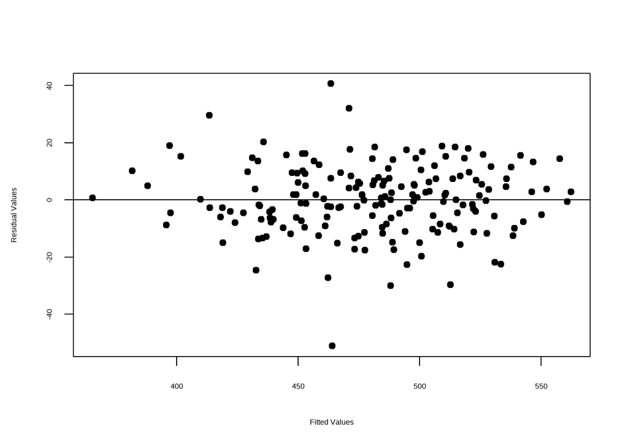

Fig.9: Residual vs Fitted plot

```r
# getting the residual values
resids <- resid(model_2)
# getting the fitted values
fits <- fitted(model_2)
# plotting residual vs fitted values using base R plot function
plot(fits, resids,  pch=19, xlab="Fitted Values", ylab="Residual Values")
# setting intercept and slope as 0,0
abline(0, 0)
```

In the residual plot above, there is a random variation of points above and below zero indicating that the linearity assumption is met. Additionally, the points are distributed along a constant width indicating that the assumption of constant variance is also met.

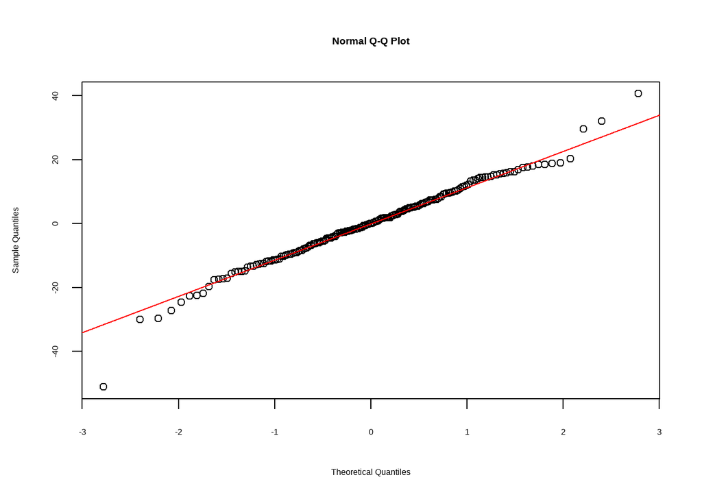

Fig.10: Quantile Quartile Plot of Residuals

```r
qqnorm(resids)
qqline(resids, col="red")
```

The normal plot shows a roughly linear distribution of points along the normal line, indicating that the assumption of normality is met for our fitted model.

### Interpretation of coefficients

From the model summary in table 3 above, the coefficient of sat_avg_crit_reading_score in our fitted model is 0.99 and the coefficient of tchadvdegree_pct_curr_yr is 0.36. As such we can conclude that a unit increase in a school’s average SAT Score in critical reading will lead to an estimated increase of 0.99 in the school’s average SAT score in Mathematics after accounting for variations in the percentage of teachers with an advanced degree in core subjects. Similarly, a unit increase in the average percentage of teachers with an advanced degree in the school will result in an estimated increase of 0.36 in the school’s average SAT score in Mathematics after accounting for variations in the schools’ average SAT score in critical reading.

## Conclusion

This analysis investigated whether the average critical reading score, student-teacher ratio in core subjects, percentage of teachers with advanced degrees, and the percentage of teachers returning from previous year (on a three year average) for traditional high schools in SC are useful predictors of the average SAT scores in mathematics in these schools. A multiple regression analysis of the response variable and these potential predictors showed that the following variables: “student-teacher ratio in core subjects” and “the percent of teachers returning from previous year (on a three year average)” are not useful predictors of Schools average SAT score in mathematics after accounting for variations in the schools’ average SAT score in critical reading and the percentage of teachers with advanced degree in the current year, 2021.